```python
import pandas as pd
import numpy as np
import matplotlib.pyplot as plt
```

# maplestory data

```python
df = pd.read_csv('C:\\Users\\default.DESKTOP-2ISHQBS\\Documents\\R\\junyper.csv')

df = df.dropna()
df = df.reset_index().drop(['n','index'],axis=1).reset_index()
df
```

|  | index | 씨앗 | 꽃 | 히솝 | 영롱한 | 환홍 | 체감 |
| --- | --- | --- | --- | --- | --- | --- | --- |
| 0 | 0 | 456 | 446.0 | 419 | 1.0 | 5.0 | 3 |
| 1 | 1 | 448 | 415.0 | 373 | 2.0 | 3.0 | 2 |
| 2 | 2 | 512 | 442.0 | 407 | 1.0 | 5.0 | 2 |
| 3 | 3 | 469 | 372.0 | 499 | 1.0 | 3.0 | 1 |
| 4 | 4 | 459 | 470.0 | 390 | 0.0 | 3.0 | 3 |
| 5 | 5 | 509 | 445.0 | 426 | 1.0 | 5.0 | 2 |
| 6 | 6 | 393 | 479.0 | 447 | 0.0 | 6.0 | 3 |
| 7 | 7 | 461 | 414.0 | 462 | 1.0 | 6.0 | 1 |

# Q1 쥬니퍼베리 씨앗을 얼만큼 먹어야 잘먹은 걸까?

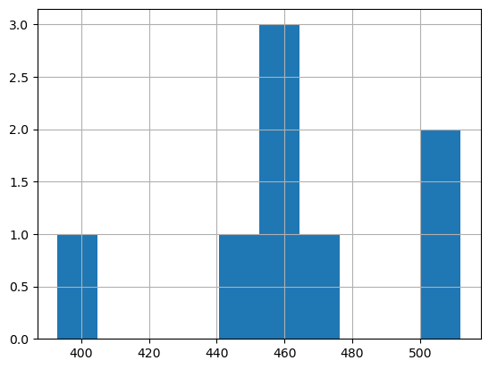

```python
df.loc[:,'씨앗'].hist()
```

- 유의성 검정을 통해 알아보자
- 모수의 분포를 정규분포로 가정하고 표본 평균과 표본 분산을 구함
- 데이터의 크기가 작아서 부정확할 수 있음

$$ \bar{X}_n = \frac{\sum^n_{i=1}X_i}{n} \\ S_n^2 = \frac{\sum^n_{i=1}(X_i - \bar{X}_n)^2}{n-1} $$

```python
n = len(df)
mean, var = df.loc[:,'씨앗'].mean(), round(df.loc[:,'씨앗'].var(),3)
mean, var
```

```
(463.375, 1392.268)
```

```python
#체감이 높은 1에 해당되는 씨앗 개수를 기준으로 잘 먹음을 고려

well_eat = df.query('체감==1').loc[:,'씨앗'].mean()
well_eat
```

```
465.0
```

- 잘먹었다고 체감되어지는 기준으로 변수를 평균내었을 때, 465의 값을 얻게 되었음
- 전체 표본평균과 위 기준으로 나온 값이 어느정도의 확률을 지니는지 알게 된다면?
- 쥬니퍼베리 씨앗을 잘 채집하였다는 확률을 알 수 있게 됨

`-` 검정통계량

- 표본평균과 표본분산을 이용하므로 t 분포를 따른다

$ t_0 = \frac{\sqrt{n}(X_i - \bar{X})}{\sqrt{S^2_n}}$

```python
t_0 = round((well_eat - mean) / np.sqrt(var/n),3)
t_0
```

```
0.123
```

```python
from scipy.stats import t,f,f_oneway

t.cdf(t_0,n-1)
```

```
0.5472179289360724
```

- 검정통계량에 따른 유의확률은 약 0.547로 평균적인 채집확률에 가까움을 알 수있음
- 이는 아직 데이터가 충분하지 않아서
- 또는 체감이 주관적인 부분이어서로 보임
- 따라서 이는 객관적 지표로 사용하기 조금 어려워 보이는 것을 알 수 있음

`-` **그렇다면 상위 10 % 안에 들 정도로 잘 먹는 씨앗의 개수는 얼마일까?**

- 이는 해당 표본평균의 신뢰구간을 통해서 구해볼 수 있을 것 같음
- 이것을 수식으로 표현하면 $0.1 = P(X_i \ge c)$로 표현 가능하며 이는 $0.1 = 1-P(X_i<c)$ 로 나타낼 수 있다

$F(\frac {c-\bar{X}}{\sqrt{S^2_n}}) = 0.9$

$\frac {c-\bar{X}}{\sqrt{S^2_n}} = F^{-1}(0.9)$

$c = F^{-1}(0.9)*\sqrt{S^2_n}+\bar{X}$

```python
fc = round(t.ppf(0.90,n-1),3)
```

```python
round(fc *np.sqrt(var/n) +mean,3)
```

```
482.042
```

```python
fc = round(t.ppf(0.10,n-1),3)
round(fc *np.sqrt(var/n) +mean,3)
```

```
444.708
```

- 하위 10%는 약 444개로 이보다 못 먹으면 운이 상당히 좋지 못하는 것을 알 수 있다.

# Q2 쥬니퍼베리씨앗과 쥬니퍼베리꽃의 분포는 같을까?

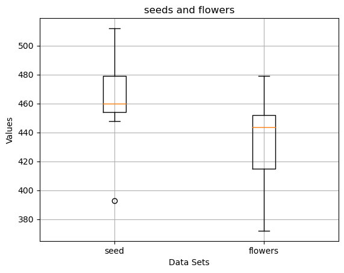

```python
data1 = df.loc[:,'씨앗']
data2 = df.loc[:,'꽃']

# 두 개의 박스플롯 그리기
plt.boxplot([data1, data2], labels=['seed', 'flowers'])
plt.title('seeds and flowers')
plt.xlabel('Data Sets')
plt.ylabel('Values')
plt.grid(True)
plt.show()
```

- 박스플랏으로 비교하기에는 애매하다
- 이는 n이 늘어남으로써 결과가 바뀔 수 있어보임

`-` 평균의 차이

- 유의성 검정을 통해 꽃과 씨앗의 표본평균을 비교함으로써 평균 차이가 나는지를 봐보려함
- 검정통계량, 분산은 동일하다고 가정
- $t=\frac{\bar X_{seed} - \bar X_{flowers} - (\mu_{seed} - \mu_{flowers})}{\sqrt{S_p^2 (1/n + 1/m)}} $

`-` **그전에 분산이 동일한지부터 검정을 하자**

- 분산의 비율을 통해 검정
- 분산의 비율은 F분포를 따름
- $\alpha = 0.05$
- $H_0 : \sigma_{seed} = \sigma_{flowers} $
- $H_1 : \sigma_{seed} \ne \sigma_{flowers} $

```python
var_flower= round(df.loc[:,'꽃'].var(),3)
var_seed= round(df.loc[:,'씨앗'].var(),3)

f0 = var_seed/ var_flower
```

```python
f.cdf(f0,n-1,n-1)
```

```
0.584792989987237
```

- 결과는 약 0.585로 기각역에 위치하지 않아 귀무가설을 기각하지 못한다.
- 따라서 서로의 분산은 같다는 증거를 얻음
- 다시 돌아와 평균의 차이를 검정해보자

`-` 모평균 차이에 대한 검정

- 유의수준 : 0.05 / 2
- $H_0 : \mu_{seed} - \mu_{flowers} = 0$
- $H_0 : \mu_{seed} - \mu_{flowers} \ne 0$

```python
mean_flower= round(df.loc[:,'꽃'].mean(),3)
mean_seed= round(df.loc[:,'씨앗'].mean(),3)

mean_seed, mean_flower
```

```
(463.375, 435.375)
```

```python
S_total = ((n-1)*var_seed + (n-1)*var_flower) / (n+n-2)
t0 = (mean_seed - mean_flower) / np.sqrt(S_total*(1/n+1/n))

(1-t.cdf(t0,n+n-2))/2
```

```
0.035128433591728236
```

`-` **그러면 쥬니퍼베리 씨앗, 쥬니퍼베리 꽃, 히솝 꽃 이 세집단의 평균이 전부 동일할까?**

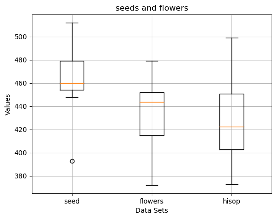

```python
data1 = df.loc[:,'씨앗']
data2 = df.loc[:,'꽃']
data3 = df.loc[:,'히솝']

# 두 개의 박스플롯 그리기
plt.boxplot([data1, data2,data3], labels=['seed', 'flowers','hisop'])
plt.title('seeds and flowers')
plt.xlabel('Data Sets')
plt.ylabel('Values')
plt.grid(True)
plt.show()
```

- 분산분석을 통해서 확인해보자
- 유의수준 : 0.05
- $H_0 : 세집단의 평균은 같다$
- $H_1 : 적어도 하나의 집단은 평균이 다르다$

```python
group1 = df.loc[:,'씨앗']
group2 = df.loc[:,'꽃']
group3 = df.loc[:,'히솝']

# 분산분석 수행
f_statistic, p_value = f_oneway(group1, group2, group3)
p_value
```

```
0.16150458209293506
```

- 유의수준보다 크므로 귀무가설을 기각하지 못한다.
- 따라서 세 집단의 평균은 같은 것인 증거를 얻었다